# BST 270: Individual project

Xiaonan Liu

# Introduction

This report aims to reproduce the figure and table presented in [“How Americans Like Their Steak”](https://fivethirtyeight.com/features/how-americans-like-their-steak/). This article presented the results from a survey on whether risk-averse people are more likely to order their steak well done. They collected survey reponses from 550 people on their preference of steak and risky events (e.g. speeding in traffic, buying riskier lottery, and skydiving). Then they produced tables and plots (which we reproduced below) to investigate this relationship.

# Packages

We first load `dplyr`, `tidyverse`, `kableExtra`, and `ggplot2` packages using `pacman`. This report is generated using R version 4.3.2.

```r
# load relevant packages
if (!require('pacman')) {
    install.packages('pacman')
}
pacman::p_load('dplyr', 'ggplot2', 'tidyverse', 'knitr', 'kableExtra')
```

Then we read in data, which was originally downloaded from [here](https://github.com/fivethirtyeight/data/blob/master/steak-survey/steak-risk-survey.csv).

```r
# Read in data
data<-read.csv("steak-risk-survey.csv", na.strings=c("","NA"))

# Rename columns to shorter readable names
names(data)<-c("ID","Lottery","Smk","Alc","Gamble","Skydiving","Drive","Cheat","Steak_ind","Steak_like","Gender","Age","Income","Edu","Location")

# Remove second row because of redundant text
data<-data[2:nrow(data),]

# Make "steak preference" variable as a factor for plotting purpose later
data$Steak_like=factor(data$Steak_like, levels=c("Well","Medium Well","Medium","Medium rare","Rare"), labels = c("Well","Medium-well","Medium","Medium-rare","Rare"))
```

There were a total of 550 participants that took the survey, which is the same number shown in the article.

# Table

In this section, we create a table showing the proportion of steak preferences among respondents who choose the riskier lottery (i.e. Lottery A) and safer lottery (i.e. Lottery B) respectively.

```r
# First we extract the two columns used to produce the frequency table and remove missing data
data1<-data[,c("Lottery","Steak_like")]%>%
  filter(!is.na(Lottery) & !is.na(Steak_like))
```

We first extract columns of interest, `Lottery` and `Steak_like`, then we remove the missing data, which lead to a total of 428 respondents left.

```r
# Create frequency table
crosstab<-data1%>%
  group_by(Steak_like)%>%
  # Compute frequency of steak preferences within Lottery A and B respectively
  summarise(
    across(Lottery, list(Risk = ~ sum(. == "Lottery A"),
                          Safe  = ~ sum(. == "Lottery B"))))%>%
  mutate(
    # Compute total number of people who prefer Lottery A and B
    N_Risk=sum(Lottery_Risk),N_Safe=sum(Lottery_Safe),
    # Compute percentage of steak preferences within Lottery A and B
    Risk_perc=pretty_dp(Lottery_Risk/N_Risk,dp=1,pct=TRUE),
    Safe_perc=pretty_dp(Lottery_Safe/N_Safe,dp=1,pct=TRUE)
    )%>%
  select(Steak_like,Risk_perc,Safe_perc)

names(crosstab)<-c("STEAK PREFERENCE","RESPONDENTS WHO CHOOSE THE \n RISKIER LOTTERY","RESPONDENTS WHO CHOOSE THE \n SAFER LOTTERY")

# Display % for the first row
crosstab[1,2]=paste0(crosstab[1,2],"%")
crosstab[1,3]=paste0(crosstab[1,3],"%")

kable(crosstab)%>%
  kable_styling(bootstrap_options = c("striped", "hover"))
```

| STEAK PREFERENCE | RESPONDENTS WHO CHOOSE THE RISKIER LOTTERY | RESPONDENTS WHO CHOOSE THE SAFER LOTTERY |
| --- | --- | --- |
| Well | 7.7% | 9.0% |
| Medium-well | 16.4 | 18.1 |
| Medium | 35.7 | 25.8 |
| Medium-rare | 35.3 | 41.2 |
| Rare | 4.8 | 5.9 |

We see that the table is the same as presented in the article.

# Plot

```r
# Remove missing data for steak preference
data2<-data%>%filter(!is.na(Steak_like))
```

Lastly, we create a barplot showing the percentages and ranking of individuals’ steak preferences from a survey of 432 steak-eating Americans.

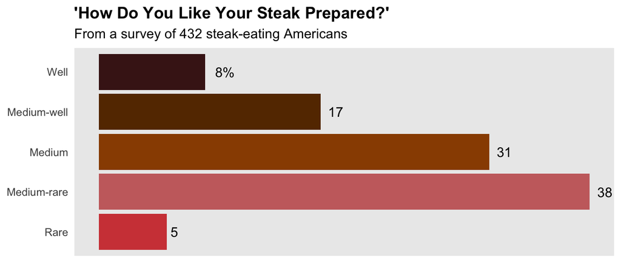

```r
# Create a data frame listing the percentage of steak preference
steak_prop<-as.data.frame(prop.table(table(data2$Steak_like)))%>%
  mutate(Prop=round(Freq*100))

# Display % in the first row
steak_prop[1,"Prop"]=paste0(steak_prop[1,"Prop"],"%")

# Create the barplot
ggplot(data=steak_prop, aes(x=Var1, y=Freq,fill=Var1)) +
  geom_text(aes(label=Prop), hjust=-0.5, colour = "black", position=position_dodge(width=0.2)) +
  geom_bar(stat="identity") +
  scale_x_discrete(limits = rev) +
  coord_flip()+ guides(fill="none") +
  scale_fill_manual(values=c("#471A1A","#663300","#994c00","#C96D6D","#D14545"))+
  theme(panel.grid.major = element_blank(), panel.grid.minor = element_blank(),axis.title.x = element_blank(),
        plot.title = element_text(face="bold"),
    axis.text.x = element_blank(),
    axis.ticks.x = element_blank(),
    axis.title.y = element_blank(),
    axis.ticks.y = element_blank())+
  labs(title="'How Do You Like Your Steak Prepared?'",subtitle="From a survey of 432 steak-eating Americans")
```

We see that the barplot is the same as presented in the article.